# Java Spring Boot & Microservices

# 1. Setup

This demo project is to explore the testing framework offer by Java and Spring. We will have unit test (and/or Context Testing to be precise), integration test, and acceptance test. The project is divided into frontend which utilize basic html, css, and javascript to render reactive web based application, and backend which expose service as API.

Here are the the system requirements for this build and the actual version:

- Eclipse IDE (4.19.0)
- Postgresql (v12.3)
- Java 8 (openjdk 8 version 1.8.0_282)
- Docker (Docker version 20.10.6)
- VS Code (1.59.0 Universal) with **Live Server Extension**

For downloading Java 8 and using it in Eclipse, please follow steps in the documentation of the previous project.

# 2. Project Overview

For the backend project. Below is the entire sturcture:

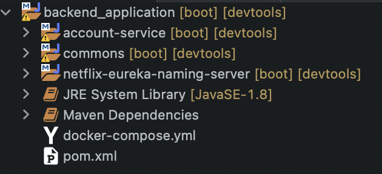

backend_structure

account-service package is the main service where most of the development and testing resides. commons package is the common utility java class that will include into account-service and future service. netflix-eureka-naming-server package will be the discovery server for the service and also future microservice. For the following, we will focus on account-service.

## 2.1 Maven Project and dependencies

For the entire project, we are build upon Spring framework (spring-boot-starter-parent:2.3.9.RELEASE). For the main service, we can see that the dependency is divided into two basic scopes: one that only will be included in testing and other will not.

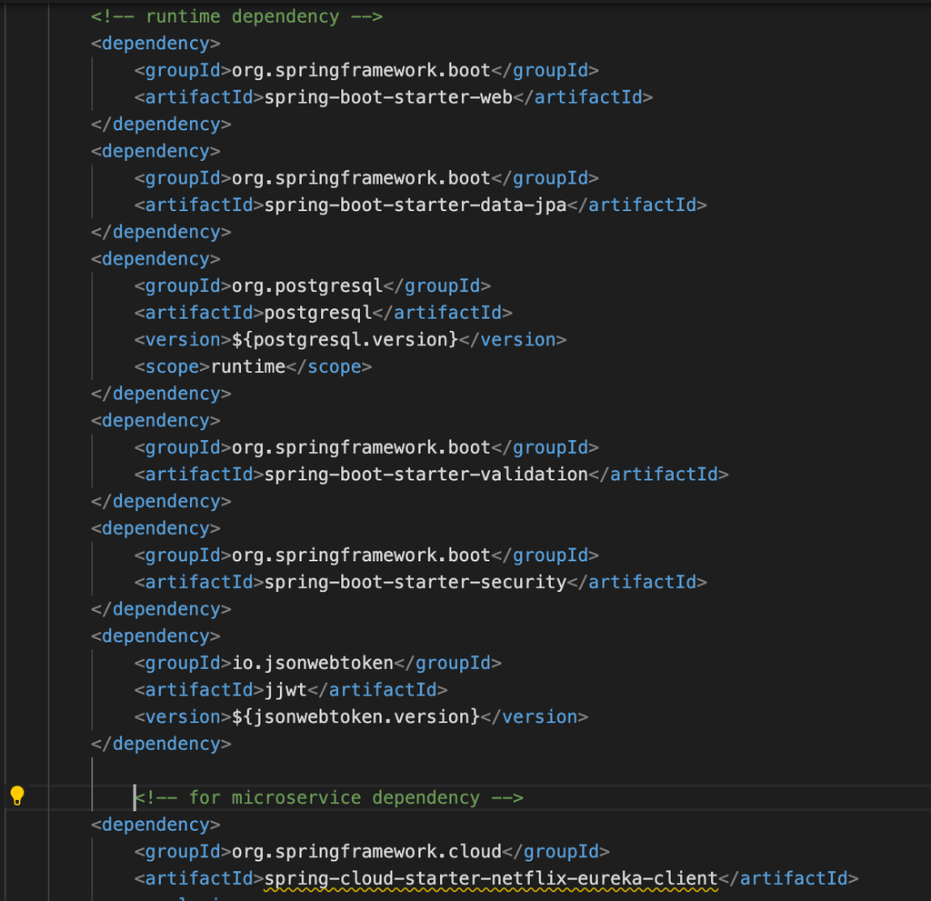

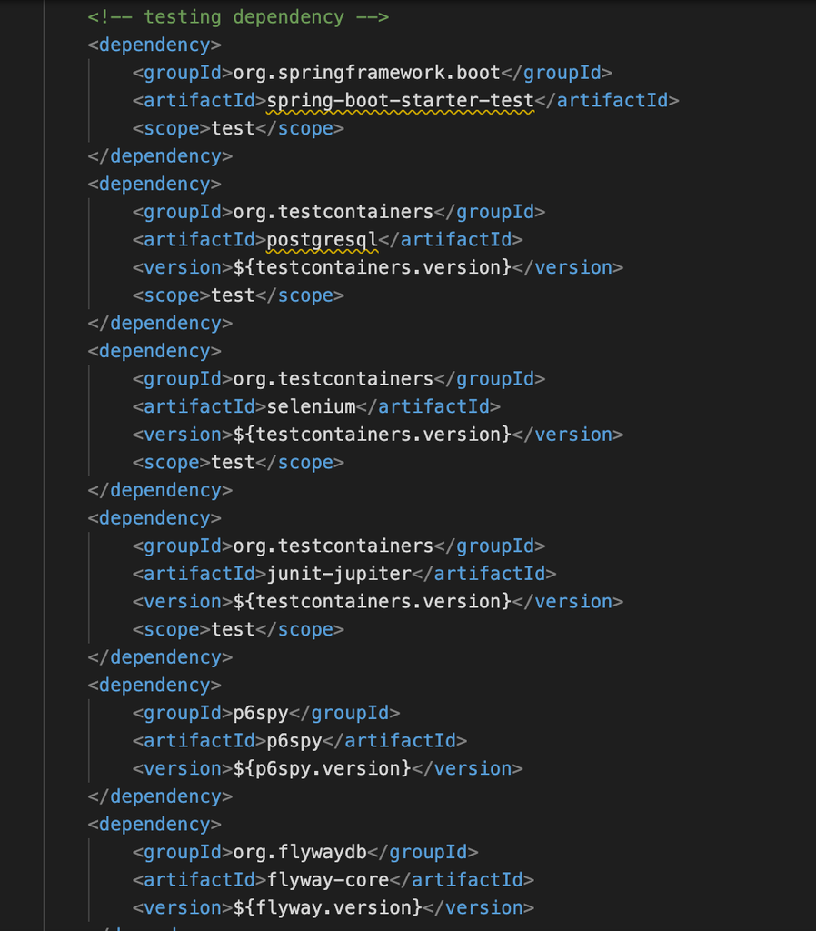

pom.xml for account-service

## 2.2 Backend Structure

All the main application codes will be under src/main/java and further divide into different components according to layer functionality. In contrast, src/test/java includes all tests.

- unit test consists of java classes in controller, repository, and service package.
- BasicIntegrationTest provides some test cases for integration test.
- StepDefinition are dedicated to Acceptence test, which are cucumber step definitions and selenium web test).

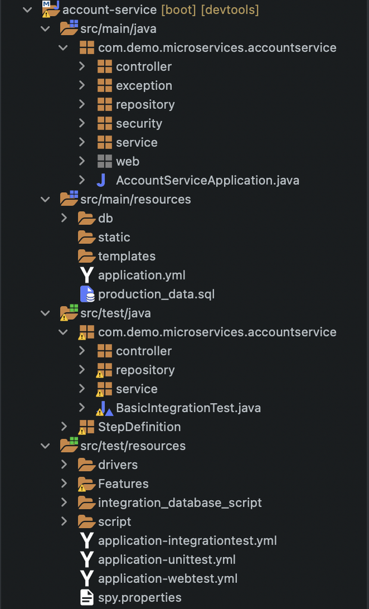

## 2.3 Frontend

The frontend is developed entirely using basic html5, css, javascript(conform with ES6), with minimal amount of css bootstrap. For development purpose, I use VS code Live Server extension which support live browser reload.

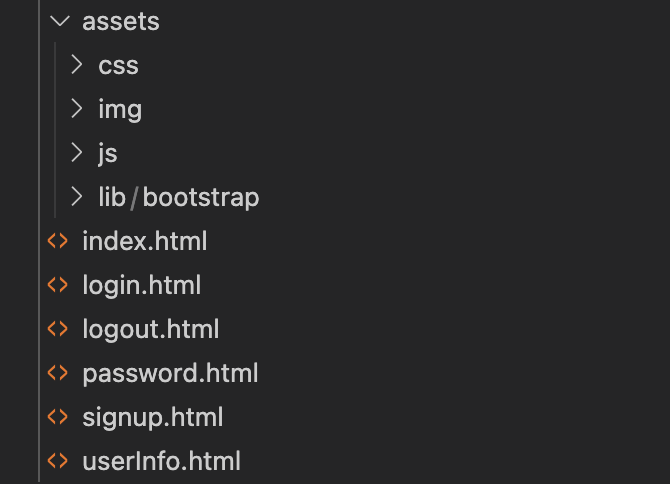

# 3. Running Application

1. Set up local database (postgresql 12.3) with default database **postgres** through default port 5432. If you want to build with source code, download link is [here](https://ftp.postgresql.org/pub/source/v12.3/postgresql-12.3.tar.gz). Also here is installation and post-installation setup [guide](https://www.postgresql.org/docs/12/installation.html).
2. Change **username** and **password** of datasource in application.yml under account-service/src/main/resources according to your local database setup.
3. Make sure port 8200 is unoccupied.
4. In Eclipse, right click NetflixEurekaNamingServerApplication.java -> Run As -> Java Application.
5. In Eclipse, right click AccountServiceApplication.java -> Run As -> Java Application.
6. Open frontend in VS code. Make sure Live Server extension is downloaded. Under index.html page, right click -> Open with Live Server. It should automatically open a browser with url http://127.0.0.1:5500/login/index.html for you.

** For future re-run, make sure to delete all the existing data from postgres database tables **roles**, **users**, **user_roles** beforehand. In linux or mac terminal, in the database, the command should look like this: **truncate * from roles** and so on.

# 4. Testing

The testing protocol we want to apply is TDD(Test-Driven Development) or better BDD(Behavioral-Driven Development). TDD is about making better design and BDD is built upon TDD with additional requirement that focus on passing scenarios of user stories. These approaches allow for incremental value creation and quality assurance. We will incorporate this design philosophy into spring framework using JUnit, Mockito, Cucumber, Selenium and so on.

[figure not shown]

## 4.1 Unit Testing

### overview

This section is the most important part of the test. It is the building block of all testing layer and is the essential to the implementation design of java object. But it is recommend to have basic design of object relation before any project begins.

### setup

We will have several key dependencies in pom.xml that needs to include for tests:

- **org.springframework.boot: spring-boot-starter-test** (offer spring boot related testing setup configuration and annotation support including JUnit which is essential that it runs every test method independently in parallel)
- **org.springframework.security: spring-security-test** (testing security related)
- **org.testcontainers: junit-jupiter** (support junit5 such that containers start for every test method or are shared between all methods of a test class)
- **org.testcontainers: postgresql**
- **p6spy: p6spy** (proxy that enables database data to be seamlessly intercepted and logged)
- **org.json: json** (not necessary, project specific, easy produce json but it is not perfect)

In this project, we will dissect the account service into three layers: Data access layer, service layer, and controller layer.

- In data access layer in the sense of Spring JPA, every implementation detail is done by Hibernate (if so choose). Therefore, the only testing here is actual interaction with the database and your specifying method of JPA repository. Generally speaking it is considered an integration test. But we included it in Unit Test is because it is specific slice of Spring context. The context setup is given by @DataJpaTest which will initialize bean and configure only on JPA component. Since we will run database in a container environment, make sure to have Docker in your machine before hand. There is one detail to note: we will use **TestEntityManager** to save the data instead of save method of **JpaRepository** (or **CrudRepository**), since the save method provided by repository are high level API and only save to cache which may not interact with the database in real time.
- In business service layer, this is where all the core logic of the application happen and the interaction with all edge layers meets, including external API and data access. We want to test only logic of our application, thus we use **mockito** to mock other layer in this case repository. Also this is where we use TDD to build our design.
- Web controllers bear many responsibilities, such as listening to the HTTP request, validating the input, calling the business logic, serializing the output, and translating the Exceptions to a proper response. In this layer, @WebMvcTest is used for testing each controller. We use **MockMvc** to test MVC component with a mocked servlet environment which means there is no Tomcat running and no http request involves - it is mocked. In this layer, we also can test the authorities where we set up in spring security with the ease.

### conclusion & opinion

1. Naming convention of the test method can be more systematic and should be a clear tangible statement.
2. The design part and testing can be improved. The central idea of the unit test should be as general as possible and shouldn’t be modified when different implementation is applied in object-oriented sense.
3. The central part to unit test in spring requires greater understanding of Object Oriented Design, Aspect Oriented Programming, JUnit and Mock. Since everything works in Spring Context, it is required to know how to configure spring beans for each test class.

## 4.2 Integretion Testing

The setup is almost identical to the Unit Test since basically we just need to initialize full spring application context and autoconfigure beans, which we will use @SpringBootTest in this case. Everything should be real except for certain third parties application that may require money for each calls, so only available during production. One caveat for our demo is that we still use **MockMvc** for mocking request which does not use real Http communication to go through Tomcat servlet container from our setup. However, since Spring Framework 5.3 (part of Spring Boot since version 2.4.0), we can use **WebTestClient** to perform real requests against MockMvc, and that is for future project to implement.

## 4.3 Acceptence Testing

### overview and setup

The additional dependency requirements are selenium and cucumber, which we will include following:

- org.testcontainers: selenium
- io.cucumber: cucumber-java
- io.cucumber: io.cucumber
- io.cucumber: io.cucumber
- org.seleniumhq.selenium: selenium-java
- com.codeborne: selenide (high level API for Selenium)
- org.seleniumhq.selenium: selenium-remote-driver
- org.seleniumhq.selenium: selenium-chrome-driver

Here we provide Cucumber feature files which contains BDD Gherkin scenario. Next, we create a empty class (e.g. CucumberIT.java) serves as **entry point** that use cucumber-junit to instruct JUnit to use Cucumber runner class. Next we create an AbstractWebTest.java annotated with @CucumberContextConfiguration along with @SpringBootTest to tell Cucumber to use this class as context configuration. Finally our step definitions will extend AbstractWebTest so spring beans get injected. Any failed test will generate screenshot and html in target/web-screenshots.

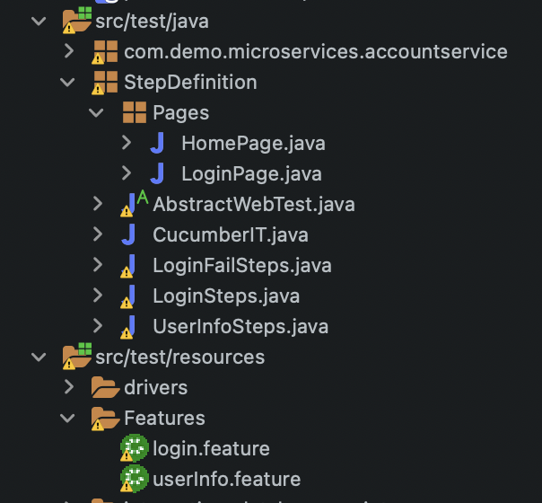

### conclusion:

1. The current setup is flawed. The testcontainer will startup before the application context and close before shutting down. This means that Eureka server (in testcontainer) is shutting down before our application de-register the client which makes it shouting error even the test cases have been passed. We need to figure out a way to start container for every cucumber scenario.
2. The remote web driver cannot be connected and set as the default driver. The possible reason is policy issue for firewall. However, this is speculation and requires additional investigation later. Hence for now we just use the driver downloaded by Selenide.
3. It is useful to adopt page object pattern that directly divide selenium into reusable object.

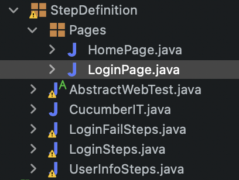

# 5 Discussion and Problems

There are flaws and incompleteness in this demo. Part of them are described in the previous section. Part of them is that we do not have the opportunity to integrate third party into our system. Part of them is that it is hard to test a module like spring security without dedicated library. However, this demo project only serves as a starting point. We may need a deeper understanding about Java and clever design to wrap around these issues in the future.